# Coursera Practical Machine Learning

Peter Mere

September 28, 2015

# Introduction

In a study (http://groupware.les.inf.puc-rio.br/work.jsf?p1=11201) by Velloso et al., six participants were asked to perform barbell lifts correctly and incorrectly in five different ways. The goal of this project is to build a prediction model on data taken from accelerometers attached to the belt, forearm, arm, and dumbell of the participants, and predict *how* they were lifting.

# Data

The training data are available here: https://d396qusza40orc.cloudfront.net/predmachlearn/pml-training.csv

The test data are available here: https://d396qusza40orc.cloudfront.net/predmachlearn/pml-testing.csv

The data for this project comes from this source: http://groupware.les.inf.puc-rio.br/har.

# Procedure

1. Load and examine the data.
2. Remove unnecessary variables.
3. Split the data into training and validation sets.
4. Train a random forest model on the training set.
5. Predict the lift type for validation set records and examine the error.
6. Predict the lift type for test set records and submit the predictions on-line.

It should be noted that as we are using random forest there is little point centering or scaling the data.

# 1. Load and examine the data.

Download the training and test data.

```r
trainingSet_full <- read.csv("https://d396qusza40orc.cloudfront.net/predmachlearn/pml-training.csv",
                        na.strings = c("NA","#DIV/0!",""))

testSet <- read.csv("https://d396qusza40orc.cloudfront.net/predmachlearn/pml-testing.csv",
                    na.strings = c("NA","#DIV/0!",""))
```

# 2. Remove unnecessary variables

## NA values

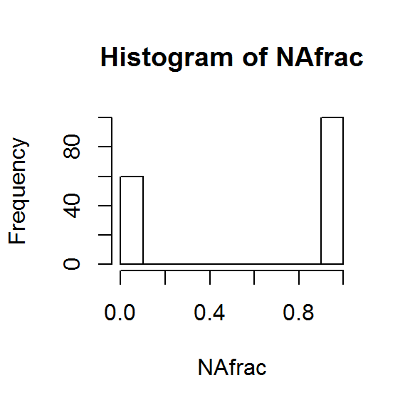

```r
NAfrac <- sapply(names(trainingSet_full), function(x) sum(is.na(trainingSet_full[,x]))/dim(trainingSet_full)[1])
hist(NAfrac)
```

The histogram above shows that the variables are either nearly all NAs, or nearly all data. Drop the variables that are mostly NAs.

```r
trainingSet_full <- trainingSet_full[,NAfrac<0.5]
```

## Irrelevant

It is clear from the variable names that the first seven are irrelevant (i.e. not accelerometer data), and they should be removed.

```r
names(trainingSet_full)[1:7]
```

```
## [1] "X"                    "user_name"            "raw_timestamp_part_1"
## [4] "raw_timestamp_part_2" "cvtd_timestamp"       "new_window"
## [7] "num_window"
```

```r
trainingSet_full <- trainingSet_full[,-(1:7)]
```

## Near zero variance

```r
library(caret)
isNZV <- nearZeroVar(trainingSet_full, saveMetrics = T)
sum(isNZV$nzv==TRUE)
```

```
## [1] 0
```

There are no near zero variance variables left, so nothing to remove.

# 3. Split the data into training and validation sets.

We will keep 20% of the training data aside in order to estimate the out of sample error for the model.

```r
set.seed(465)
inTrain = createDataPartition(trainingSet_full$classe, p = 0.8, list=FALSE)
trainingSet = trainingSet_full[inTrain,]
valdtnSet = trainingSet_full[-inTrain,]
```

# 4. Train a random forest model on the training set.

Random forest is a very powerful categorisation machine learning method. However, it can take a long time to create a model, so we will trim some parameters in order to minimise the processing overhead.

```r
set.seed(987)
library(randomForest)
modelRF <- randomForest(classe ~ ., data=trainingSet, ntree=50, mtry=7, importance=TRUE, proximity=TRUE)
modelRF  # A summary.
```

```
##
## Call:
##  randomForest(formula = classe ~ ., data = trainingSet, ntree = 50,      mtry = 7, importance = TRUE, proximity = TRUE)
##                Type of random forest: classification
##                      Number of trees: 50
## No. of variables tried at each split: 7
##
##         OOB estimate of  error rate: 0.62%
## Confusion matrix:
##      A    B    C    D    E class.error
## A 4456    4    1    2    1 0.001792115
## B   17 3007   13    0    1 0.010204082
## C    0   14 2716    8    0 0.008035062
## D    1    0   23 2547    2 0.010104936
## E    0    0    3    7 2876 0.003465003
```

This shows that the estimated out-of-bag error rate is estimated at 0.62%, which should be similar to the out of sample error rate.

# 5. Predict the lift type for validation set records and examine the error.

```r
valPred <- predict(modelRF, valdtnSet)
confMat <- confusionMatrix(valPred,valdtnSet$classe)
confMat
```

```
## Confusion Matrix and Statistics
##
##           Reference
## Prediction    A    B    C    D    E
##          A 1115    3    0    0    0
##          B    1  756    2    0    0
##          C    0    0  682    4    2
##          D    0    0    0  639    1
##          E    0    0    0    0  718
##
## Overall Statistics
##
##                Accuracy : 0.9967
##                  95% CI : (0.9943, 0.9982)
##     No Information Rate : 0.2845
##     P-Value [Acc > NIR] : < 2.2e-16
##
##                   Kappa : 0.9958
##  Mcnemar's Test P-Value : NA
##
## Statistics by Class:
##
##                      Class: A Class: B Class: C Class: D Class: E
## Sensitivity            0.9991   0.9960   0.9971   0.9938   0.9958
## Specificity            0.9989   0.9991   0.9981   0.9997   1.0000
## Pos Pred Value         0.9973   0.9960   0.9913   0.9984   1.0000
## Neg Pred Value         0.9996   0.9991   0.9994   0.9988   0.9991
## Prevalence             0.2845   0.1935   0.1744   0.1639   0.1838
## Detection Rate         0.2842   0.1927   0.1738   0.1629   0.1830
## Detection Prevalence   0.2850   0.1935   0.1754   0.1631   0.1830
## Balanced Accuracy      0.9990   0.9975   0.9976   0.9967   0.9979
```

# 6. Predict the lift type for test set records and submit the predictions on-line.

```r
testPred <- predict(modelRF, testSet)
testPred
```

```
##  1  2  3  4  5  6  7  8  9 10 11 12 13 14 15 16 17 18 19 20
##  B  A  B  A  A  E  D  B  A  A  B  C  B  A  E  E  A  B  B  B
## Levels: A B C D E
```

These predictions scored 100% on submission.